# Question

Find all solutions to the equation.

$${5}x^{2}-x-{18}=0$$

## Answerlist

- $x=-10$
- $x=\frac{-10}{5}$
- $x=-9$
- $x=\frac{-9}{5}$
- $x=-8$
- $x=\frac{-8}{5}$
- $x=-7$
- $x=\frac{-7}{5}$
- $x=-6$
- $x=\frac{-6}{5}$
- $x=-5$
- $x=\frac{-5}{5}$
- $x=-4$
- $x=\frac{-4}{5}$
- $x=-3$
- $x=\frac{-3}{5}$
- $x=-2$
- $x=\frac{-2}{5}$
- $x=-1$
- $x=\frac{-1}{5}$
- $x=1$
- $x=\frac{1}{5}$
- $x=2$
- $x=\frac{2}{5}$
- $x=3$
- $x=\frac{3}{5}$
- $x=4$
- $x=\frac{4}{5}$
- $x=5$
- $x=\frac{5}{5}$
- $x=6$
- $x=\frac{6}{5}$
- $x=7$
- $x=\frac{7}{5}$
- $x=8$
- $x=\frac{8}{5}$
- $x=9$
- $x=\frac{9}{5}$
- $x=10$
- $x=\frac{10}{5}$

# Solution

Rewrite the given quadratic equation:

$${5}x^{2}-x-{18}=0$$

You’ll want to factor the left-side expression.

Set up a box with what you know… Notice that the leading (quadratic) coefficient, $a=5$, is prime. This allows us to be more confident in how this expression factors.

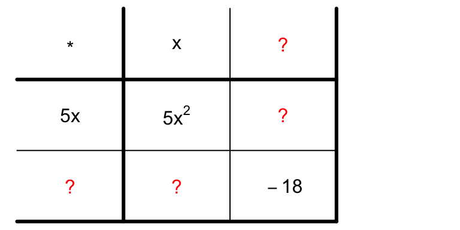

You can get this by guessing and checking. To make a smart guess, find a pair of integers that multiply to get $-18$, and use those…

Eventually, because $(9)\cdot(-2)=-18$, you will guess the following factored form:

$$({5}x+{9})\cdot(x-{2})=0$$

And you will check it with a box to see that it works.

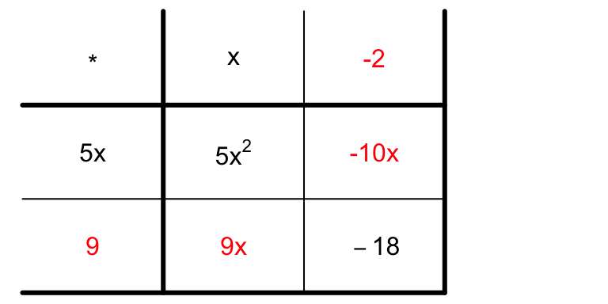

$${5}x^{2}-{10}x+{9}x-{18}$$

Combine like terms.

$${5}x^{2}-x-{18}$$

So it worked! (Because it matches the given standard-form expression.) Thus, in factored form, the expression is:

$$({5}x+{9})\cdot(x-{2})$$

Now, remember the **equation**.

$$({5}x+{9})\cdot(x-{2})=0$$

Use the zero-product property.

- First solution:
  $${5}x+{9}=0$$
  $$5x=-9$$
  $$x=\frac{-9}{5}$$
- Second solution:
  $$x-{2}=0$$
  $$x=2$$

# Meta-information

extype: mchoice exsolution: 0001000000000000000000100000000000000000 exname: factor_quadratic